# Lab 1 - 7331 Data Mining

## Dan Freeman, Ireti Fasere, Timothy McWilliams, & Peter Kouvaris

### 1 - Business Understanding (10%)

### Preparing Python for Data Exploration

```python
#imports for data-preprocessing
import pandas as pd
import numpy as np

#viz libraries
import matplotlib.pyplot as plt
import seaborn as sns
%matplotlib inline
```

```python
#import data
data_file = '../data/adult.csv'
df = pd.read_csv(data_file)
```

```python
df['workclass'] = df['workclass'].str.replace('?', 'Unknown')
df['occupation'] = df['occupation'].str.replace('?', 'Unknown')
df['native_country'] = df['native_country'].str.replace('?', 'Unknown')
```

### 2 - Meaning & Data Types (10%)

```python
df.head(3)
```

[output not shown]

### 3 - Data Quality Review (15%)

### 4 - Sample Statistics (10%)

### 5 - Visualization (15%)

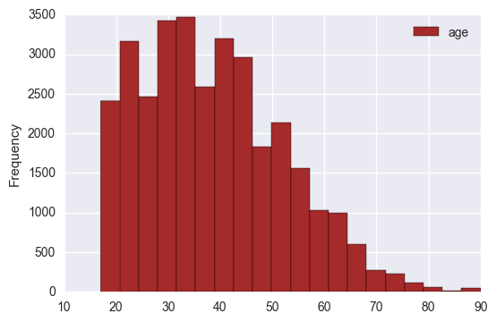

```python
#Histogram
#visualizing the age distribution of the census data
mydata.age.plot.hist(bins=20, color ='brown')
plt.legend()
```

The age distribution between 20years and 55years were quite frequent. The lowest age was about 20years old and the highest is about 90 years old. Finally, the histogram is skewed to the right or positively skewed.

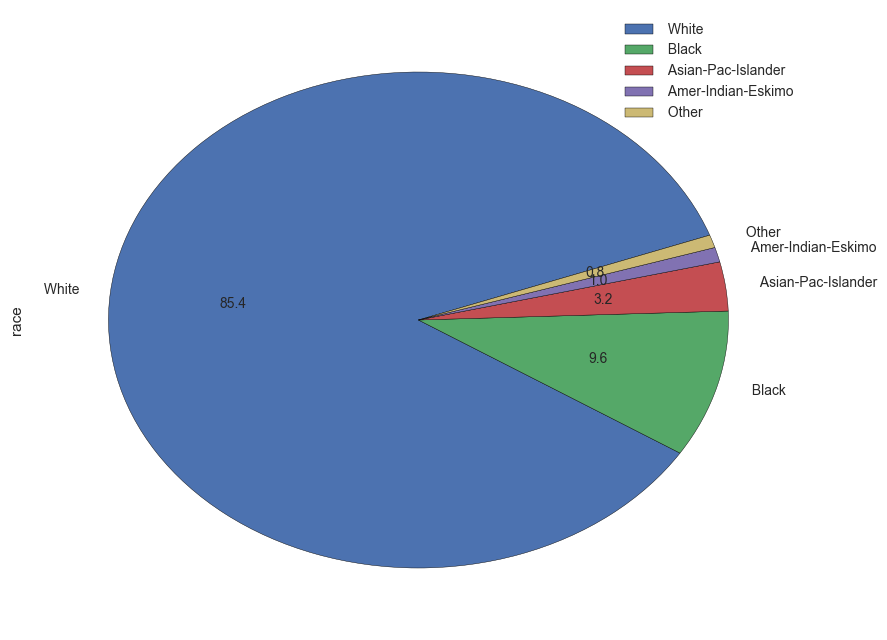

```python
# Pie Chart
#visualizing race of the census data
mydata.race.value_counts().plot(kind='pie', autopct='%.1f',fontsize=10, startangle = 20, figsize=(10, 8))
plt.legend()
```

85.4% of the census data is White, 9.6% is Black, Asian-Pac-Islander accounted for 3.2% of the population, American -Indian-Eskimo accounted for 1.0% of the population, while Other race accounted for just 0.8% of the total population. The White population is dominant here accounting for 85.4% of the total population. Followed by the Black population accounting for only 9.6% of the total population.

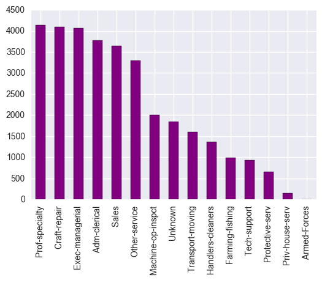

```python
#Barplot
#visualizing occupation of the census data
mydata['occupation'].value_counts().plot(kind='bar', color = 'purple')
```

The highest recorded occupation accounted for Over 4000 individual that belong to the Prof-specialty, Exec-managerial, and Craft-repair occupation respectively. The lowest recorded occupation is the Armed-Forces, and Priv-house-serv accounting for less than 100 and 200 respectively. About 1800 unknown was accounted for or the individuals did not disclose their occupation. We can assume they are either unemployed or self-employed,and preferred not to respond.

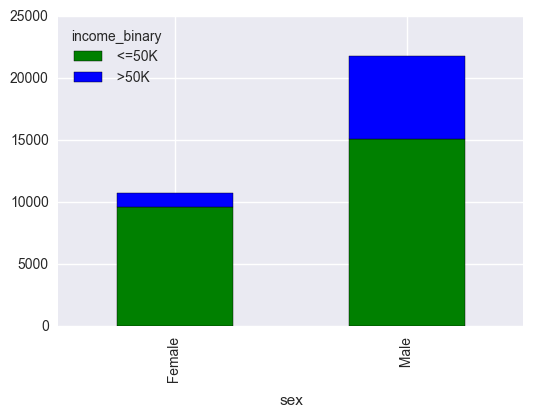

```python
#Barplot
#visualizing sex vs income-binary of the census data
income_sex_counts = pd.crosstab([df['sex']], df.income_binary)
income_sex_counts.plot(kind='bar', stacked=True,color=['green','blue'])
```

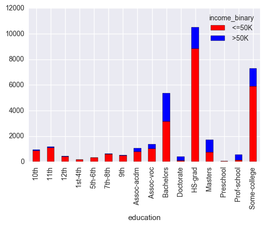

```python
income_education_counts = pd.crosstab([df['education']], df.income_binary)
income_education_counts.plot(kind='bar', stacked=True,color=['red','blue'])
```

# 6- Feature Relationships (15%)

### 7 - Feature : Class Relationship Explanation (10%)

### 8 - Additional Features Discussion (5%)

### 9 - Exceptional Work (10%)